# **Lecture05 - Introducción a las redes neuronales recurrentes**

# **Memoria a corto/largo plazo (LSTM)**

Breve resumen de las puertas hasta ahora...

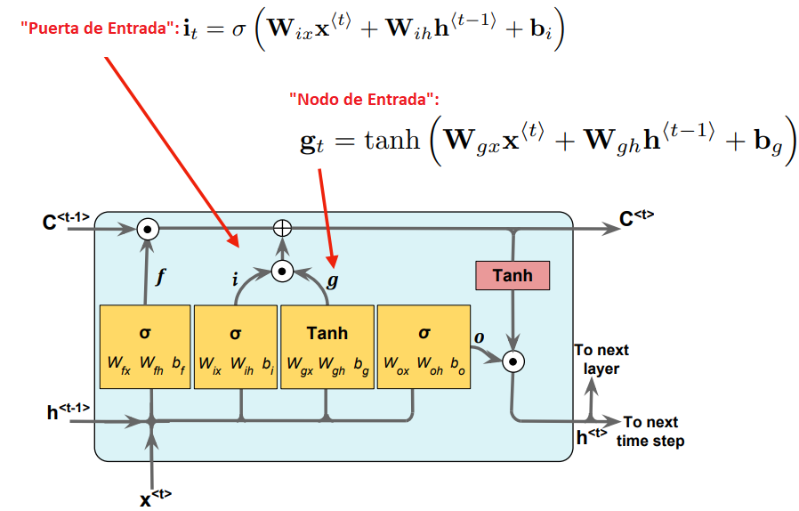

# **Memoria a corto/largo plazo (LSTM)**

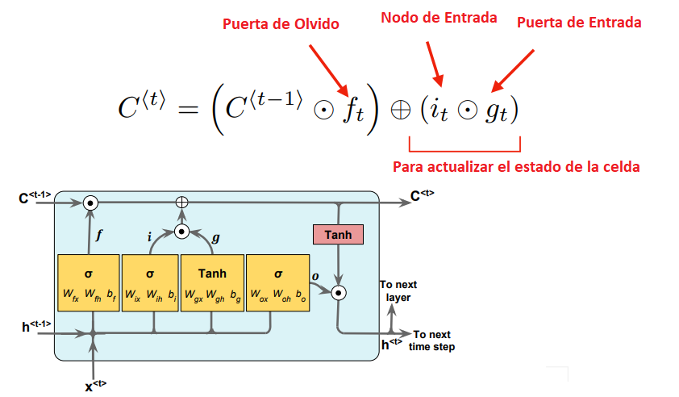

# **Memoria a corto/largo plazo (LSTM)**

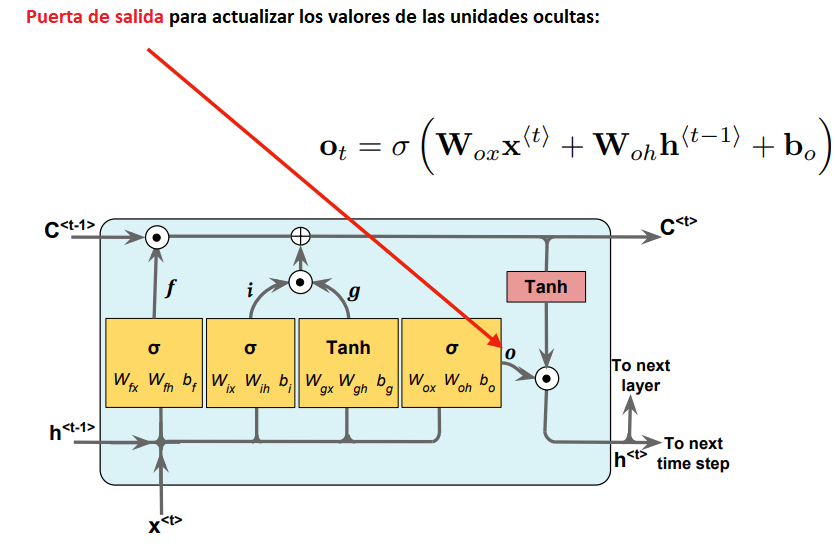

# **Memoria a corto/largo plazo (LSTM)**

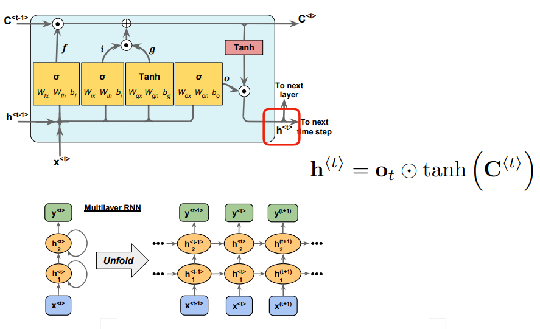

# **Memoria a corto/largo plazo (LSTM)**

- **Todavía es popular y se usa ampliamente en la actualidad.**
- **Un enfoque reciente relacionado es la Unidad Recurrente Cerrada (GRU por sus siglas en inglés)** Cho, Kyunghyun, Bart Van Merriënboer, Caglar Gulcehre, Dzmitry Bahdanau, Fethi Bougares, Holger Schwenk, and Yoshua Bengio. "Learning phrase representations using RNN encoder-decoder for statistical machine translation." arXiv preprint arXiv:1406.1078 (2014). https://arxiv.org/abs/1406.1078
- **Buen artículo que explora los LSTM y los compara con los GRU** Jozefowicz, Rafal, Wojciech Zaremba, and Ilya Sutskever. "An empirical exploration of recurrent network architectures." In International Conference on Machine Learning, pp. 2342-2350. 2015. http://proceedings.mlr.press/v37/jozefowicz15.pdf

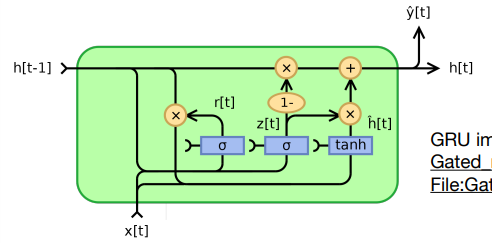

Fuente de imagen GRU: https://en.wikipedia.org/wiki/Gated_recurrent_unit#/media/File:Gated_Recurrent_Unit,_base_type.svg

# **Implementación de un clasificador RNN/LSTM**

- Diferentes formas de modelar texto (secuencias)
- Modelando secuencias con RNNs
- Diferentes tipos de tareas de modelado de secuencias
- Retropropagación a través del tiempo
- Memoria a corto/largo plazo (LSTM)
- **Many to one RNNs**
- Clasificadores con RNNs en PyTorch

# **Diferentes tipos de tareas de modelado de secuencias**

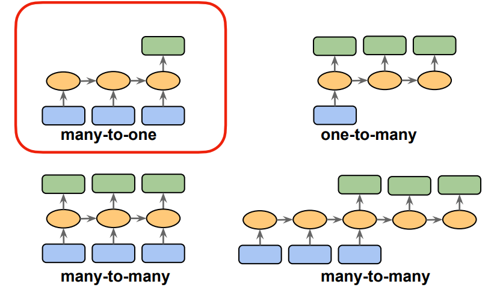

Figura basada en: The Unreasonable Effectiveness of Recurrent Neural Networks by Andrej Karpathy (http://karpathy.github.io/2015/05/21/rnn-effectiveness/)

# **Un enfoque clásico para la clasificación de textos: modelo de bolsa de palabras**

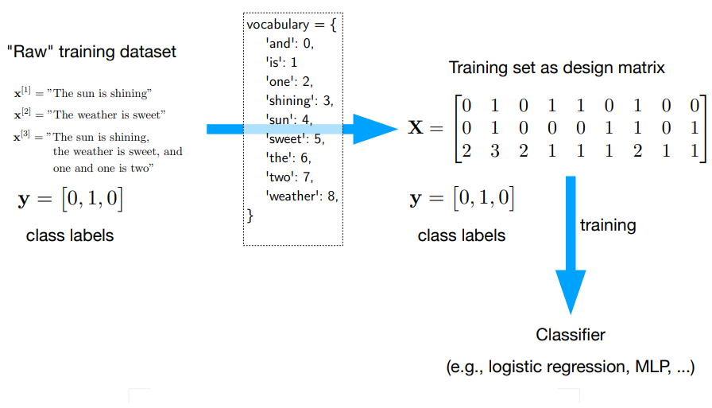

Raschka & Mirjalili. Python Machine Learning 3rd Ed. https://github.com/rasbt/python-machine-learning-book-3rd-edition/blob/master/ch08/ch08.ipynb

# **RNN Paso 1): Construyendo el vocabulario**

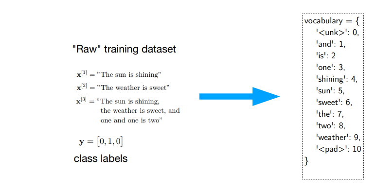

# **RNN Paso 2): Entrenamiento de textos de ejemplo para índices**

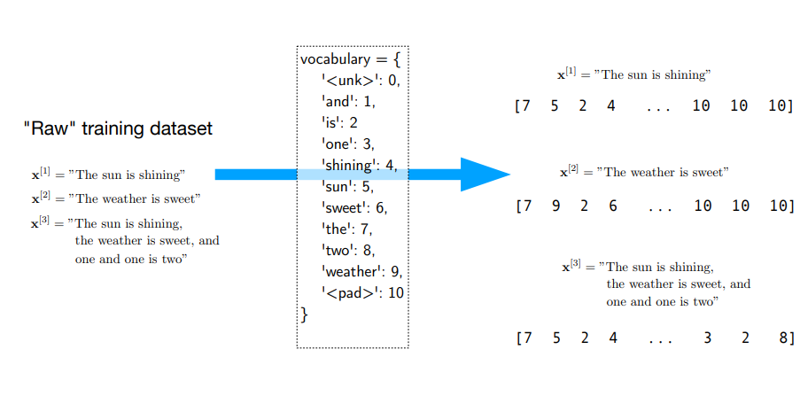

# **RNN Paso 3): Indices para la representación One-Hot**

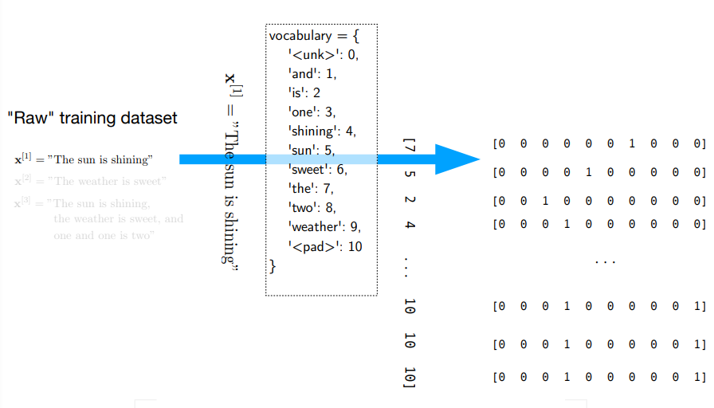

# **RNN, paso 4): One-Hot to Real a través de la matriz de incrustación**

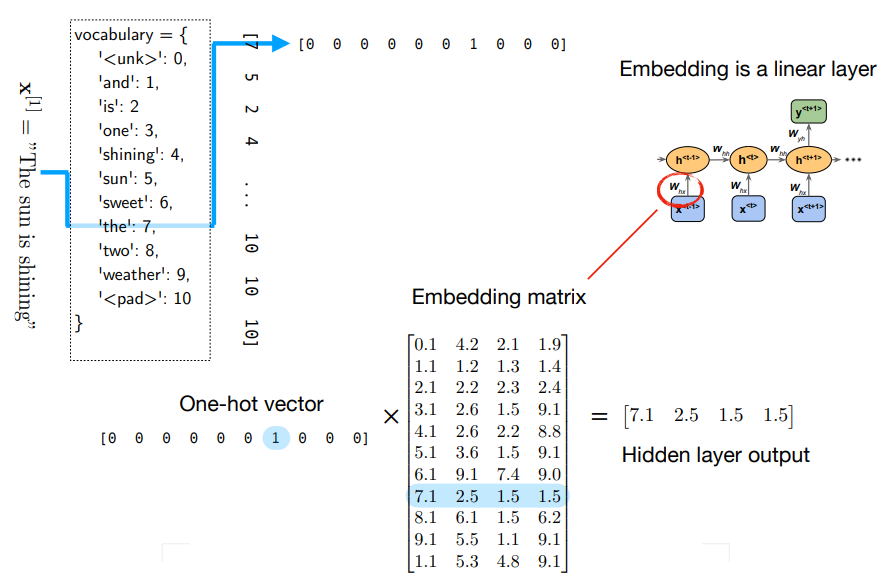

# **En la práctica, omita los pasos 3 y 4 y...**

### usar una función de búsqueda (torch.nn.Embedding)

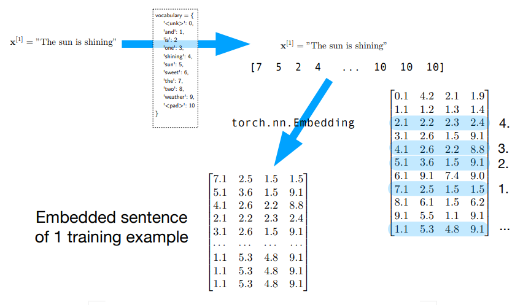

# **Conjunto de datos de IMDB**

- Conjunto de datos para la clasificación de sentimientos binarios
- 25,000 reseñas de películas altamente polares para entrenamiento y 25,000 para pruebas

https://ai.stanford.edu/~amaas/data/sentiment/

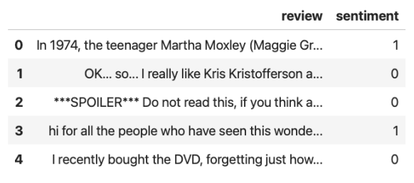

# **Buen recurso**

[figure not shown]

https://github.com/bentrevett/pytorch-sentiment-analysis

https://colab.research.google.com/github/pytorch/text/blob/master/examples/legacy_tutorial/migration_tutorial.ipynb#scrollTo=EC054Wlr0-xB

# **Clasificadores RNN en PyTorch**

- Diferentes formas de modelar texto (secuencias)
- Modelando secuencias con RNNs
- Diferentes tipos de tareas de modelado de secuencias
- Retropropagación a través del tiempo
- Memoria a corto/largo plazo (LSTM)
- Many to one RNNs
- **Clasificadores con RNNs en PyTorch**